# Exploring Weather Trends

## Author - Pradeep Gurunathan

### Summary

In this Weather Trends project we will be analysing the local and global temperature data and also compare temperature trends where I reside to overall global tempature trends.

### Introduction

We all know that global temperature is increasing and according to NOAA 2019 Global Climate Summary, the combined land and ocean temperature has increased at an average rate of 0.07°C (0.13°F) per decade since 1880; however, the average rate of increase since 1981 (0.18°C / 0.32°F) is more than twice as great.

This increaing in temperature is contributed by many factors such as burning fossil fuels, deforestation and also unscientific agriculture and farming.

In this report I have considered Dublin city temparature data and it has been compared to the global temperature data. After considering all the above factors for increase in global temperature,I have analysed and visualized the data to find the similarities and differences between global temperature trends and local temperature trends.

### Tools used

A). SQL for downloading two datasets from the main database.

```
Query used:-

1). To generate 'city.csv'.

    select * from city_data where city='Dublin'

2). To generate 'global.csv'.

    select * from global_data
```

B). Used Python for importing the dataset, data cleaning and data visualization.

### Data Importing

I have used pandas library to import two datasets one for Dublin city temperature data('city.csv') and second for global temperature data('global.csv')

```python
import pandas as pd
city_data = pd.read_csv('city.csv')
global_data= pd.read_csv('global.csv')
```

'City.csv' dataset consists of average temperature over the years for Dublin city.

'global.csv' dataset consists of average global temperature for more than 250 years.

### Data Cleaning

Using pandas library I have dropped the rows with missing values.

```python
city_data=city_data.dropna()
global_data=global_data.dropna()
```

### Visualization chart

##### Line chart with local and global temperature trends.

Two Moving average for 10 years and 50 years is calculated for getting a smooth data. Moving average for 50 years gives more smoother data when compared to moving average for 10 years.

line chart is plotted for Dublin city vs global average temperature.

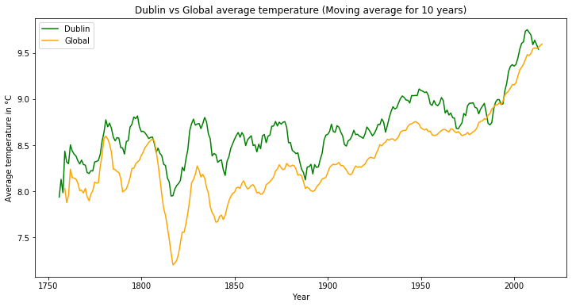

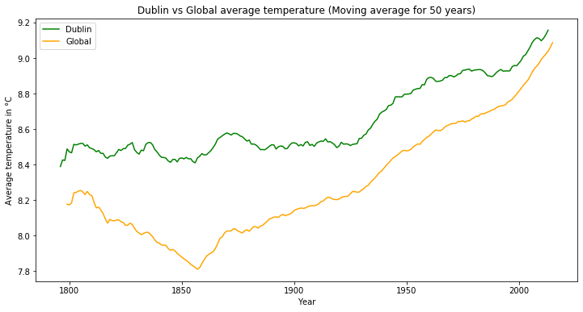

```python
import matplotlib.pyplot as plt
%matplotlib inline
fig, ax = plt.subplots(figsize=(12,6))
ax.plot(city_data['year'],city_data['avg_temp'].rolling(window=10).mean(), color='g',label='Dublin')
ax.plot(global_data['year'],global_data['avg_temp'].rolling(window=10).mean(), color='orange',label='Global')
plt.xlabel('Year')
plt.ylabel('Average temperature in °C')
plt.title('Dublin vs Global average temperature (Moving average for 10 years)')
leg = ax.legend();
plt.show()

fig, ax = plt.subplots(figsize=(12,6))
ax.plot(city_data['year'],city_data['avg_temp'].rolling(window=50).mean(), color='g',label='Dublin')
ax.plot(global_data['year'],global_data['avg_temp'].rolling(window=50).mean(), color='orange',label='Global')
plt.xlabel('Year')
plt.ylabel('Average temperature in °C')
plt.title('Dublin vs Global average temperature (Moving average for 50 years)')
leg = ax.legend();
plt.show()
```

### Observation

Following observations can done from the above charts:-

1). From first line chart,

- With a moving average for 10 years we see that local average temperature for Dublin city is very close and even below the Global average temperature line.
- Highest average temperature between Dublin and Global average temperature was seen during 1820's.
- During 1980's and 1990's the Dublin city average temperature was below Global average temperature.
- Average temperature range for Dublin city is around 8°C to 9.7°C.
- Average Global temperature ranges from 7.3°C to 9.5°C.

2). From Second line chart,

- With a moving average for 50 years we see that local average temperature for Dublin city is higher than Global average temperature, but we cant say that there is huge difference between the lines.
- It is clear that during 19th century (1800 to 1900) the difference in average temperature for Dublin city and Global temperature is higher when compare to 20th century.
- Both Dublin and Global average temperature are getting very closure since 20th century.
- Average temperature range for Dublin city is around 8.4°C to 9.1°C.
- Average Global temperature ranges from 7.8°C to 9°C.